# Vaccination and voting patterns in the United States: analysis of COVID-19 and flu surveys from 2010 to 2022

Minttu Rönn

2023-Mar-02

# Part 2

The online data are continuously updated. The code needs to be amended to accommodate for additional months of data

### FIGURE 2

State-level correlation between 2020 vote share for Biden in 2020 presidential elections (x-axis) and flu vaccine coverage (y-axis) by age (rows) and by flu season (columns). Washington DC excluded from the figure.

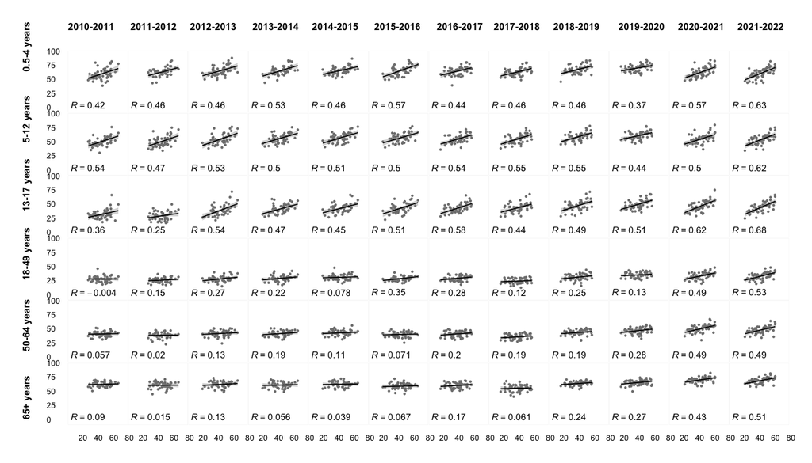

### FIGURE 3

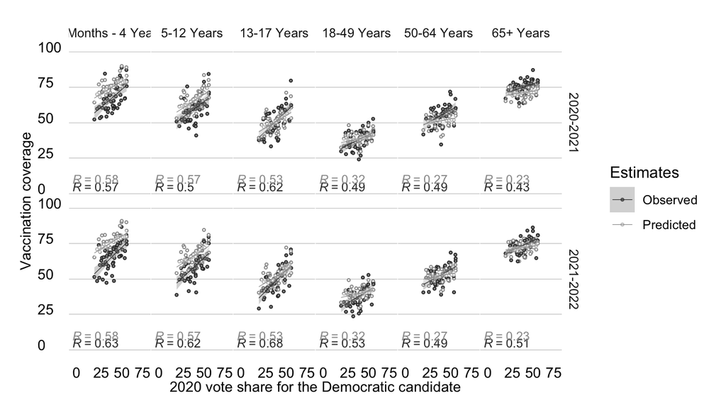

### FIGURE 1 D

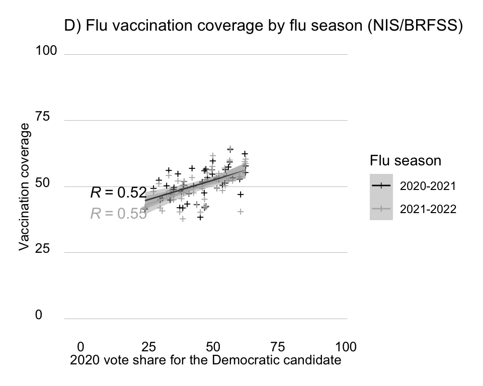

### SUPPLEMENTAL FIGURE S4 B

Relative difference in flu vaccine covearge by state between flu seasons: flu season 2021-2022 compared against 2020-2021. Data NIS/BRFSS

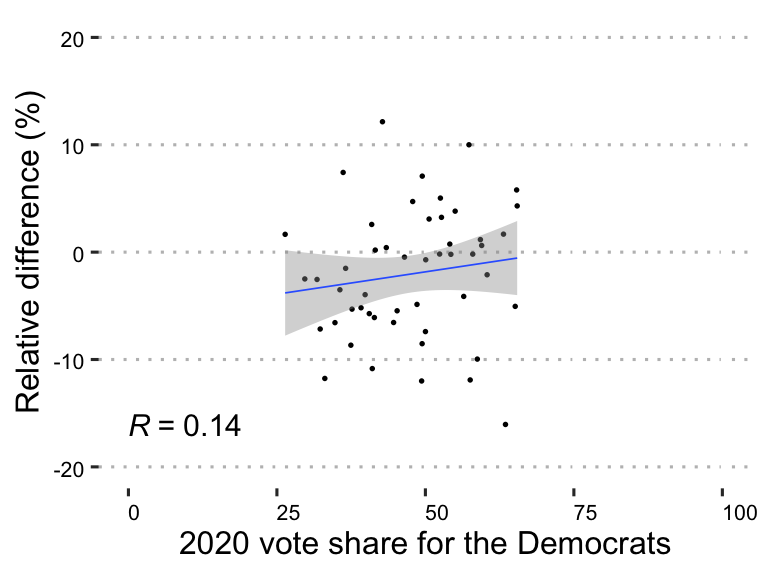

### FIGURE S5

State level flu vaccination coverage (NIS-FLU) by age (rows) and by HHS region (columns), organized by flu season 2010-2021 (x-axis). HHS regions* are ordered by 2020 vote share**: Region 1 has the highest share for Democrats and Region 7 has the lowest vote share. The seasons during the COVID-19 pandemic (2020-2021, 2021-2022) are highlighted with orange. Data: NIS-FLU, BRFSS

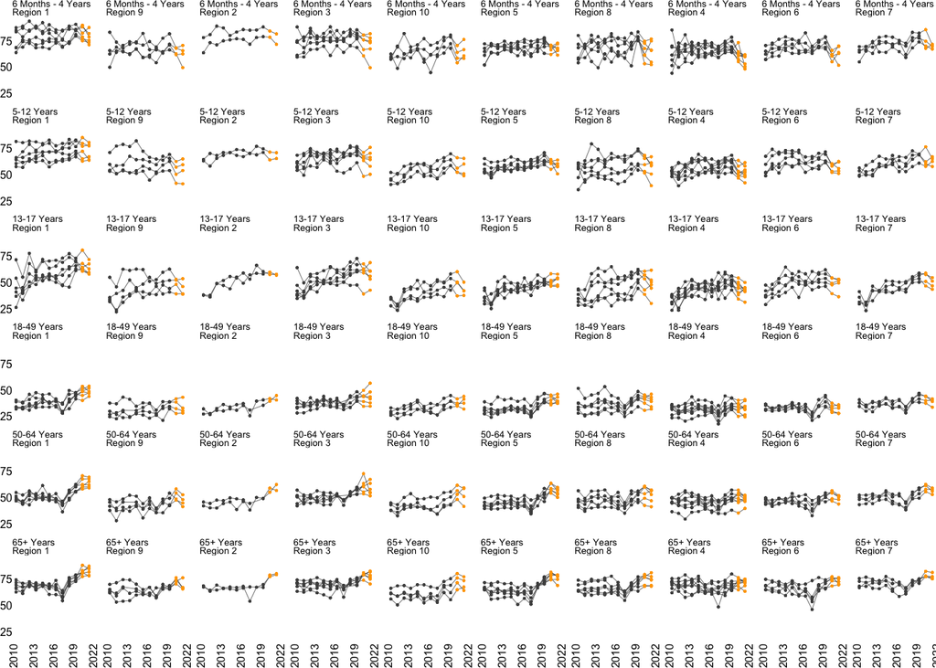

*) HHS Regions

- Region 1: Connecticut, Maine, Massachusetts, New Hampshire, Rhode Island, and Vermont
- Region 2: New Jersey, New York (not included: Puerto Rico, and the Virgin Islands)
- Region 3: Delaware, District of Columbia, Maryland, Pennsylvania, Virginia, and West Virginia
- Region 4: Alabama, Florida, Georgia, Kentucky, Mississippi, North Carolina, South Carolina, and Tennessee
- Region 5: Illinois, Indiana, Michigan, Minnesota, Ohio, and Wisconsin
- Region 6: Arkansas, Louisiana, New Mexico, Oklahoma, and Texas
- Region 7: Iowa, Kansas, Missouri, and Nebraska
- Region 8: Colorado, Montana, North Dakota, South Dakota, Utah, and Wyoming
- Region 9: Arizona, California, Hawaii, Nevada (not included: American Samoa, Commonwealth of the Northern Mariana Islands, Federated States of Micronesia, Guam, Marshall Islands, and Republic of Palau)
- Region 10: Alaska, Idaho, Oregon, and Washington

**) 2020 vote share used in this instance to demonstrate the ranking of HHS regions